# Ford GoBike Data Exploration

## by Asmaa Mostafa

## Investigation Overview

In this investigation,i would like to look into riders characteristics that can be used to predict their trips durations and numbers. The characteristics include (gender, age, and user_type) with time and locations.

## Dataset Overview

The dataset consist of 3254325 rides from june 2017 to April 2019 with 16 features ( duration_sec ,start_time ,end_time ,start_station_id ,start_station_name ,start_station_latitude ,start_station_longitude ,end_station_id ,end_station_name ,end_station_latitude ,end_station_longitude ,bike_id, user_type ,member_birth_year,member_gender and bike_share_for_all_trip)

## Trip Duration Distribution

Trip duration distribed among a large range of values, from about 1 minute as lowest duration to 1430 minute as highest duration with peak point = 500 second ~ 8 minute.

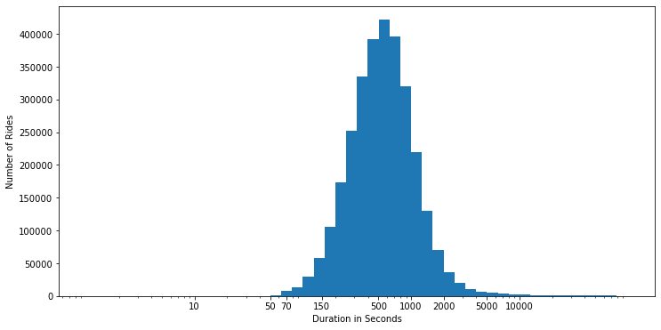

```python
# Trip duration distribution in log scale
log_binsize = 0.1
bins = 10 ** np.arange(0, np.log10(df_gobikeford['duration_sec'].astype(float).max())+log_binsize, log_binsize)
ticks=([10,50,70,150,500,1000,2000,5000,10000])
plt.figure(figsize=[12, 6])
ax=plt.hist(data = df_gobikeford, x = 'duration_sec', bins = bins)
plt.xscale('log')
labels = ['{}'.format(v) for v in ticks]
plt.xticks(ticks,labels)
plt.xlabel('Duration in Seconds')
plt.ylabel('Number of Rides')
plt.show()
```

## Users Type Trip Duration

Subscriber users trip duration less than customer users trip duration.However customer users percentage are only 11.3% but they shared 23.3% from total trip durations and this considers high ratio compared to their ratio of total users.

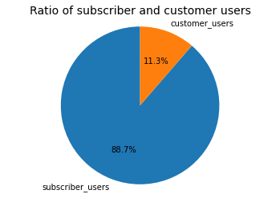

```python
# Ratio of users type (subcriber-customer)
subscriber_users=df_gobikeford[df_gobikeford.user_type =='Subscriber'].user_type.count()
customer_users=df_gobikeford[df_gobikeford.user_type =='Customer'].user_type.count()
total_users=df_gobikeford.user_type.count()

plt.pie([subscriber_users/total_users*100,customer_users/total_users*100] ,startangle=90,autopct='%1.1f%%',labels=['subscriber_users','customer_users']);
plt.axis('equal');
plt.title('Ratio of subscriber and customer users', fontsize = 14)
plt.show()
```

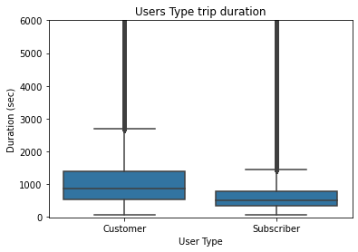

```python
# plot relationship between user type and duration
base_color = sb.color_palette()[0]
sb.boxplot(data=df_gobikeford, x='user_type', y='duration_sec', color=base_color)
plt.ylim([-10, 6000])
plt.xlabel('User Type')
plt.ylabel('Duration (sec)')
plt.title('Users Type trip duration')
```

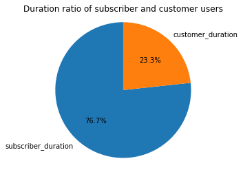

```python
#plot duration ratio to user type
#plt.figure(figsize = (14, 8))
subscriber_duration=df_gobikeford[df_gobikeford.user_type =='Subscriber'].duration_sec.sum()
customer_duration=df_gobikeford[df_gobikeford.user_type =='Customer'].duration_sec.sum()
total_duration=df_gobikeford.duration_sec.sum()

plt.pie([subscriber_duration/total_duration*100,customer_duration/total_duration*100] ,startangle=90,autopct='%1.1f%%',labels=['subscriber_duration','customer_duration']);
plt.axis('equal');
plt.title('Duration ratio of subscriber and customer users', fontsize = 12)
plt.show()
```

## Users Gender

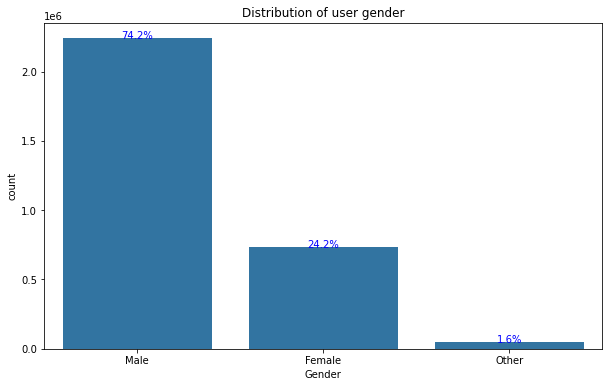

```python
# plot distribution of gender
plt.figure(figsize=[10, 6])
base_color = sb.color_palette()[0]
gender_order = df_gobikeford['member_gender'].value_counts().index
sb.countplot(data = df_gobikeford, x = 'member_gender', color = base_color, order=gender_order)
plt.title('Distribution of user gender')
plt.xlabel('Gender')
# plot gender precent on the bar chart
total_gender=df_gobikeford['member_gender'].count()
gender_counts = df_gobikeford['member_gender'].value_counts()
locs, labels = plt.xticks()
for loc, label in zip(locs, labels):
    gender_number = gender_counts[label.get_text()]
    pct_string = '{:0.1f}%'.format(gender_number/total_gender*100)
    plt.text(loc, gender_number-8, pct_string, ha='center', color='b')

plt.show()
```

## Trip Duration Across Gender and Age

For all gender types, the age range of 20-40 has the longest trip duration also age from 50 -60 have surprising performance with long rides.

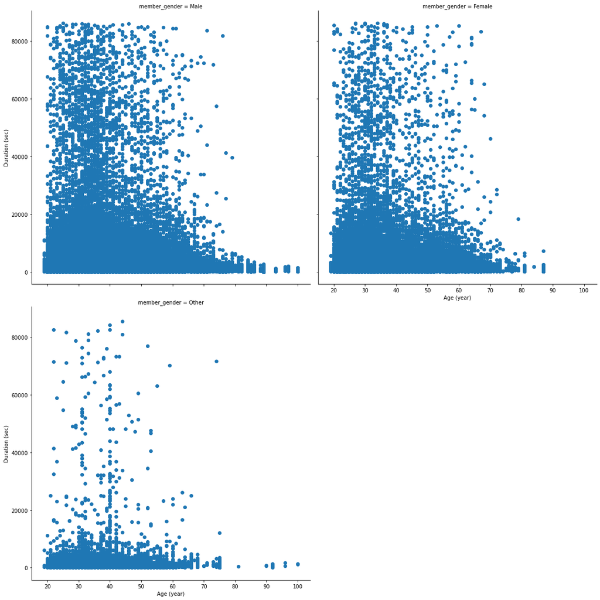

```python
plt.figure(figsize = [12,6])
user_types = sb.FacetGrid(data = df_gobikeford, col = 'member_gender', col_wrap = 2, height = 8)
user_types.map(plt.scatter, 'member_age', 'duration_sec')
user_types.set_xlabels('Age (year)')
user_types.set_ylabels('Duration (sec)')
plt.show()
```

## Day Hours Distribution Across User Type And Gender

For all subscribers users gander the heighest trip rate fall between 8am and 6pm that may be related to working hours althought cutomer users rate distarbued among day hours with high rate at 5pm forall customers user gender.

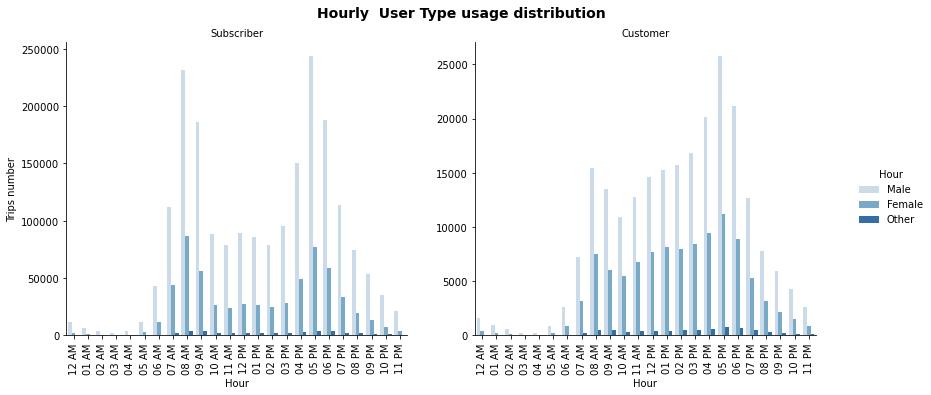

```python
g = sb.catplot(data=df_gobikeford.sort_values(by='hour'), x='start-hour', col="user_type", hue='member_gender', kind='count', sharey = False,palette='Blues')
g.fig.set_figwidth(13)
g.set_axis_labels("Hour", "Trips number")
g._legend.set_title('Hour')
g.set_titles("{col_name}")
g.fig.suptitle('Hourly  User Type usage distribution', y=1.03, fontsize=14, fontweight='semibold');
g.set_xticklabels(rotation=90);
```

## Weekdays Distribution Across User Type And Gender

The usage rate between customers and subscribers of each gender is almost similar.Female customers littel bit greater than female subscribers. All genders of customers usage are more on the weekends, while subscribers usage during the weekday.

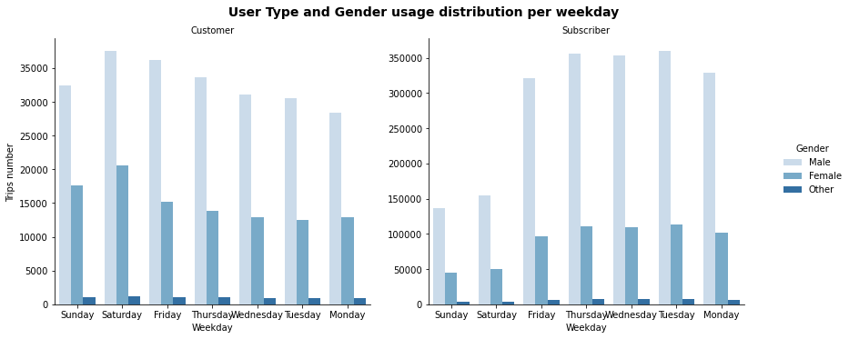

```python
g = sb.catplot(data=df_gobikeford, x='day_name', col="user_type", hue='member_gender', kind='count', sharey = False,palette='Blues')
g.fig.set_figwidth(13)
g.set_axis_labels("Weekday", "Trips number")
g._legend.set_title('Gender')
g.set_titles("{col_name}")
g.fig.suptitle(' User Type and Gender usage distribution per weekday', y=1.03, fontsize=14, fontweight='semibold');
```

## Months Distribution Across User Type And Gender

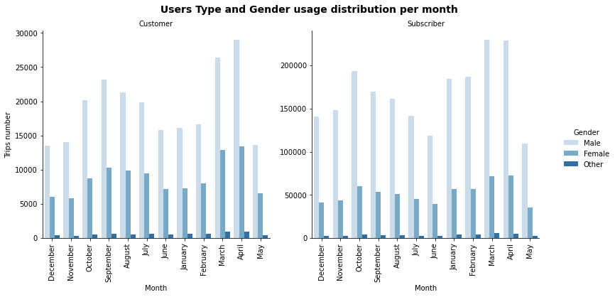

```python
g = sb.catplot(data=df_gobikeford, x='month_name', col="user_type", hue='member_gender', kind='count', sharey = False,palette='Blues')
g.fig.set_figwidth(12)
g.set_axis_labels("Month", "Trips number")
g._legend.set_title('Gender')
g.set_titles("{col_name}")
g.fig.suptitle(' Users Type and Gender usage distribution per month', y=1.03, fontsize=14, fontweight='semibold');
g.set_xticklabels(rotation=90);
```

## Most Start and End Stataions trips rate per users type

We can see that the most commonly stations used either to( start or end) for both customers and subscribers are:

while there are more customers at San Francisco Ferry Building (Harry Bridges Plaza) as start station and The Embarcadero at Sansome St station as end station than other (start,end) statio.

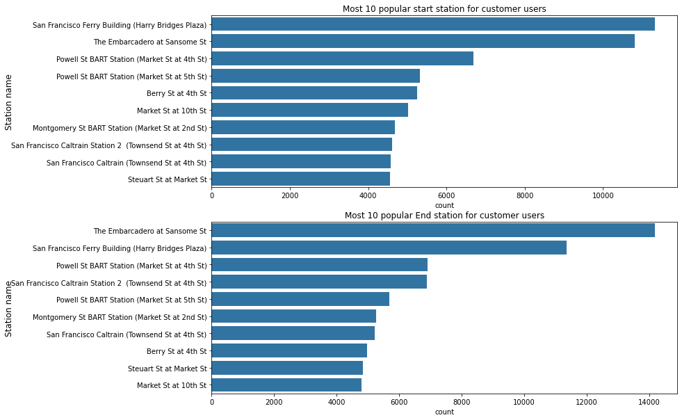

```python
#Plot most 10 start stations for customer users
fig,ax=plt.subplots(2,1,figsize=[12,10])

sorted_counts=df_gobikeford.query('user_type == "Customer"').start_station_name.value_counts().index[:10]
sb.countplot(data = df_gobikeford.query('user_type == "Customer"'),y='start_station_name' ,order=sorted_counts, color= base_color ,ax=ax[0] ) ;

sorted_counts=df_gobikeford.query('user_type=="Customer"').end_station_name.value_counts().index[:10]
sb.countplot(data = df_gobikeford.query('user_type=="Customer"'), y='end_station_name' ,order=sorted_counts, color= base_color ,ax=ax[1]);

plt.sca(ax[0])
plt.title('Most 10 popular start station for customer users', fontsize = 12)
plt.ylabel('Station name', fontsize = 12,va='center_baseline')
#plt.xticks(rotation=90)

plt.sca(ax[1])
plt.ylabel('Station name', fontsize = 12,va='center_baseline')
plt.title('Most 10 popular End station for customer users', fontsize = 12)
#plt.xticks(rotation=90)
```

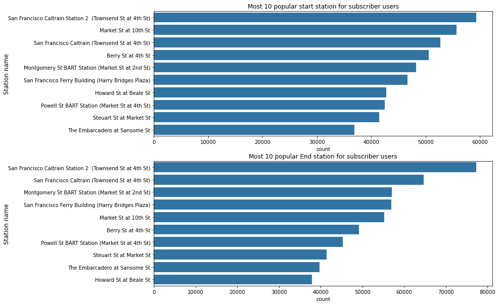

```python
#Plot most 10 start stations for subscriber  users
fig,ax=plt.subplots(nrows=2,ncols=1,figsize=[12,10])

sorted_counts=df_gobikeford.query('user_type == "Subscriber"').start_station_name.value_counts().index[:10]
sb.countplot(data = df_gobikeford.query('user_type == "Subscriber"'),y='start_station_name' ,order=sorted_counts, color= base_color ,ax=ax[0] ) ;

sorted_counts=df_gobikeford.query('user_type =="Subscriber"').end_station_name.value_counts().index[:10]
sb.countplot(data = df_gobikeford.query('user_type =="Subscriber"'), y='end_station_name' ,order=sorted_counts, color= base_color ,ax=ax[1]);

plt.sca(ax[0])
plt.title('Most 10 popular start station for subscriber users', fontsize = 12)
plt.ylabel('Station name', fontsize = 12,va='center_baseline')
#plt.xticks(rotation=90)

plt.sca(ax[1])
plt.ylabel('Station name', fontsize = 12,va='center_baseline')
plt.title('Most 10 popular End station for subscriber users', fontsize = 12)
```